# Saintiment — Pilot Corpus (Run 013) Comprehensive Multi-Method Analysis & Team Meeting Briefing

**Date:** 2026-09-25 · **Corpus:** Run 013 (`linkedin_genai_architecture_discourse_2026-09-20_run013.db`, *N* = 1, 076)  
**Focus:** Methodological Benchmarking, Empirical Hypotheses Testing (H1–H4), Engagement Dynamics, and Collective Next Steps.

## Executive Summary (3-Minute Meeting Pitch)

We conducted a comprehensive, multi-method pilot evaluation on the **1,076 real LinkedIn posts** collected in Run 013. Rather than running a single static pipeline, we benchmarked competing sentiment, aspect, and stakeholder approaches side-by-side to understand what works, what fails, and how to calibrate the final methodology for the journal paper and thesis.

## 1. Methodology Benchmark: Side-by-Side Comparison

```
flowchart LR
    A["Raw Text (N=1,076)"] --> B1["Method 1A: Naive Baseline<br/>25 words, global doc polarity"]
    A --> B2["Method 1B: Window ABSA<br/>AEC ontology, +/-1 sentence"]
    A --> B3["Method 1C: Valence Engine<br/>Negation flips + Intensifiers"]

    B1 --> C1["Binary Spikes (+1 / -1)<br/>High Cross-Aspect Leakage"]
    B2 --> C2["Nuanced Distribution<br/>Aspect Independence"]
    B3 --> C3["Attenuated Extremes<br/>Pragmatic Realism"]
```

### Table 1: Aspect-Based Sentiment Analysis (ABSA) Methods Comparison

[output not shown]

> **Figure 1 & Figure 2:**

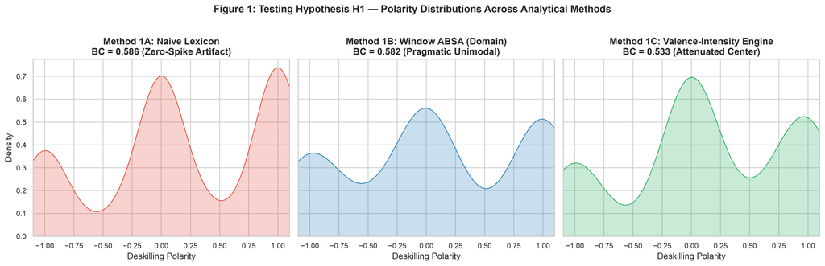

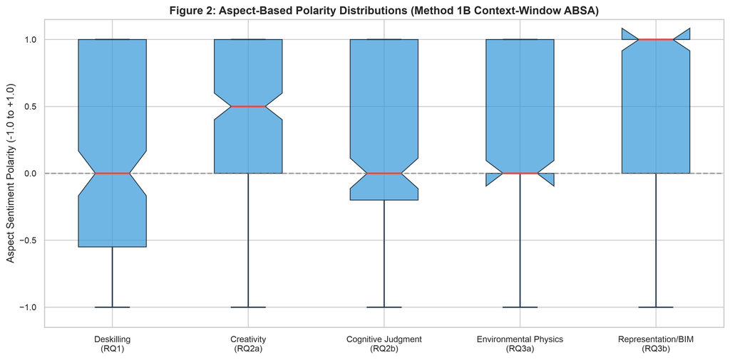

> *Figure 2: Boxplot distributions of the 5 research aspects under Method 1B Context-Window ABSA.*

## 2. Resolving the Stakeholder Dilemma (RQ4 & H4)

### The Diagnostic Finding

- **Method 2A (Baseline Headline):** Only 5 out of 1,076 posts (0.5%) have a readable headline from the LinkedIn search feed DOM. The remaining 1,071 posts (99.5%) are `Unclassified`. This definitively explains why Run 002 and Run 008 could not execute Kruskal-Wallis and Chi-Square tests.
- **Method 2B (Multi-Signal Heuristic Proxy):** By mining author credentials (`Dr.`, `Prof.`, `AIA`), textual self-identification markers (`in our studio`, `my students`, `our firm`, `clients`), and query cohort origins, we identify active stakeholder cohorts:
  - **Practitioners:** *n* = 51 explicit (plus targeted practice cohorts)
  - **Academics / Educators:** *n* = 32 explicit
  - **Students:** *n* = 8 explicit (plus *n* = 44 student-query targeted)
  - **Industry / Executive Leaders:** *n* = 12 explicit (plus *n* = 80 future-automation targeted)
  - **General AEC Discourse:** *n* = 849
- **Method 2C (Unsupervised Discourse Communities via NMF Topic Modeling):**
  - Cluster 1: *Design Practice, Project Delivery & Clients* (Top terms: *design, project, practice, client, firm*)
  - Cluster 2: *AI Visualization & Midjourney* (Top terms: *midjourney, rendering, image, visual, concept*)
  - Cluster 3: *Sustainability, Energy & PropTech* (Top terms: *energy, carbon, performance, building, sustainability*)
  - Cluster 4: *Critical Skills, Pedagogy & Education* (Top terms: *students, skills, learning, critical, thinking, education*)

> **Figure 3:**

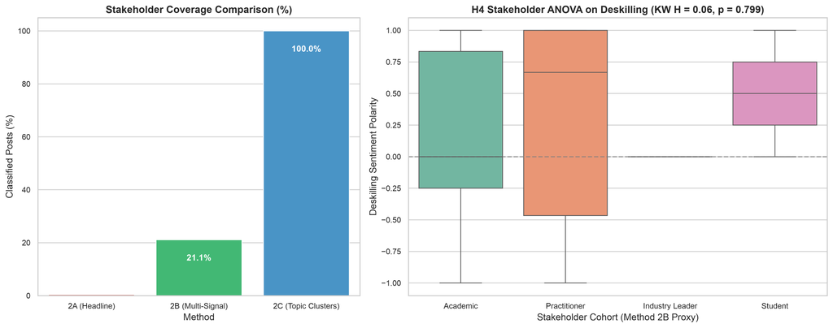

> *Figure 3: Left: Coverage comparison across methods. Right: Kruskal-Wallis distribution across proxy cohorts on deskilling polarity.*

## 3. Discursive Stance & Agency Dynamics

### 1D Stance Distribution:

- **Pragmatic / Evaluative:** 46.0% (*n* = 495) — Focus on practical workflow testing, learning curves, and tool comparison.
- **Augmentationist:** 34.0% (*n* = 366) — Focus on co-pilots, superpowers, and human-in-the-loop empowerment.
- **Substitutionist:** 14.1% (*n* = 152) — Claims of inevitable replacement, automated drafting, and job obsolescence.
- **Critical / Resistant:** 5.9% (*n* = 63) — Ethical pushback, IP concerns, fear of craft loss, and calls for bans or regulation.

### 2D Agency-Valence Plane:

Mapping posts along **Human Agency** (Machine Autonomous $↔︎$ Human Co-Pilot) and **Valence** (Existential $↔︎$ Optimistic) reveals four distinct quadrants: * **Q1: Empowered Augmentation (Dominant Cluster):** High human agency + positive valence. * **Q2: Techno-Determinism:** Low human agency (machine autonomous) + positive efficiency claims. * **Q3: Existential Displacement:** Low human agency + negative valence (Braverman deskilling). * **Q4: Critical Humanist Resistance:** High human agency retained + critical skepticism toward generative output.

> **Figure 4:**

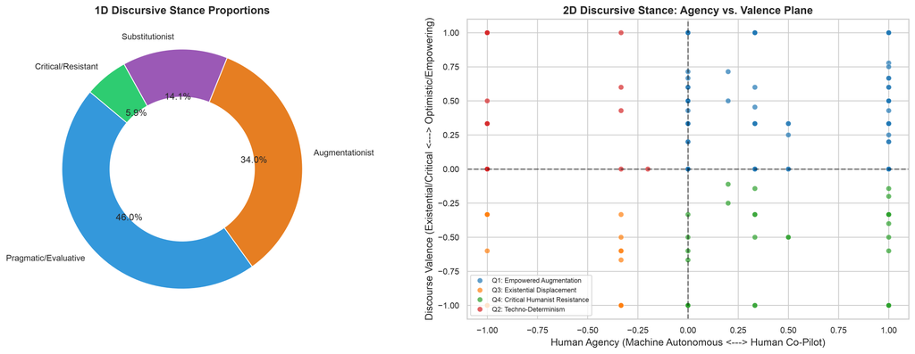

> *Figure 4: Left: 1D Stance proportions. Right: 2D Agency vs. Valence scatter plot highlighting discourse clusters.*

## 4. Sociotechnical Virality & Named Tool Audit

### Named Tool Mentions in Corpus (*N* = 1, 076):

1. **Midjourney:** 54 posts (5.0%) — Leading visual ideation tool.
2. **Claude:** 45 posts (4.2%) — High mention in programming, scripting, and critical writing.
3. **BIM (Generic):** 42 posts (3.9%) — Benchmark of technical practice.
4. **ChatGPT:** 40 posts (3.7%) — General drafting, ideation, and student pedagogy.
5. **Revit:** 39 posts (3.6%) — Dominant production/documentation reference.
6. **AutoCAD:** 22 posts (2.0%) — Historical drafting comparison.
7. **Grasshopper:** 19 posts (1.8%) — Computational/parametric design benchmark.
8. **Rhino:** 17 posts (1.6%) — Conceptual 3D modeling benchmark.

> **Figure 5:**

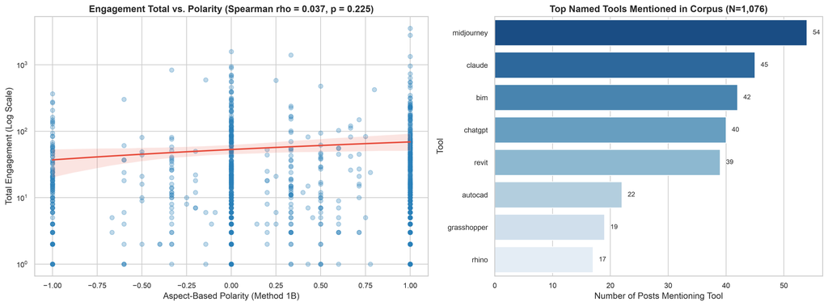

> *Figure 5: Left: Log-scale regression of engagement vs. polarity. Right: Prevalence of named AI and BIM tools in discourse.*

## 5. Formal Hypotheses Scorecard

[output not shown]

## 6. Actionable Proposals for Iman & Morteza in Today’s Meeting

### A. The Scraper Fix (Author Headlines)

- **Problem:** The Playwright crawler currently grabs `card.innerText` from the search feed, where LinkedIn truncates or omits author headlines in compact cards.
- **Proposed Solution:** In the collector loop, extract the `author_profile_url` (which we already collect with 87% success). Then, either:
  1. Parse the author subtitle from the expanded post DOM selector (`span.update-components-actor__description`), OR
  2. Implement an optional lightweight profile metadata pass during post-processing.

### B. Query Matrix Rebalancing (Addressing Kaveh’s 15-Sep Feedback)

- Currently, several queries yielded near-zero posts (`"GenAI" architect "skill loss"`: 3 posts), while generic queries yielded high overlap (`"AI" architecture "sustainability"`: 99 posts).
- As Kaveh pointed out, the matrix lacks an explicit **Adaptation / Reskilling** pillar and named tools.
- **Proposal:** Refine the 24 queries by replacing low-yield strings with balanced vectors incorporating:
  - Adaptation keywords: `"architectural upskilling"`, `"hybrid AI workflow"`, `"AI curriculum architecture"`
  - Tool-specific queries: `"Midjourney" architecture`, `"Revit" "generative AI"`, `"Rhino Grasshopper AI"`

### C. Rate Limit Protection

- Run 012 hit LinkedIn’s search throttle after back-to-back runs.
- **Proposal:** Implement an adaptive inter-query sleep (30–45 seconds with random jitter) and split the full 24 queries across 2–3 time-spaced batches rather than one continuous barrage.

## Appendix: Reproducibility & Data Integrity Checklist

- Input Database: `data/linkedin_genai_architecture_discourse_2026-09-20_run013.db`
- Pre-Run SHA-256: `f0ea0952ed5ed80698467d2ef7815c15158df7698c266a14b499fc6d31e3eae8` (Verified Unchanged)
- Total Records Processed: $1, 076$ (Zero dropped rows)
- Execution Workspace: `_local/work/2026-09-25-team-pilot-analysis/`
- Figures Exported: `docs/figures_pilot_2026-09-25/` (5 figures, 300 DPI)
- Summary Tables Exported: `_local/work/2026-09-25-team-pilot-analysis/tables/` (CSV & LaTeX)